# BBC - Laboratoires 3-4

## Transcriptomique

- Professeur: Carlos Peña (carlos.pena@heig-vd.ch)
- Assistant: Brochet Xavier (xavier.brochet@heig-vd.ch)

Date: Printemps 2019

## Objectifs pédagogiques

> Pour réaliser ce laboratoire, du vocabulaire et des notions de base en biologie seront introduits ou perfectionnés. A la fin du laboratoire, l’étudiant devrait:
> - Comprendre le type d'informations contenues dans les puces à ADN (microarray ou DNA chip en anglais)
> - Savoir identifier des gènes exprimés differentiellement dans une condition vs. une autre (malade vs. sain)
> - Comprendre les notions de test statistique et de p-valeur
> - Comprendre comment l'apprentissage automatique peut être utilisé pour prédire si un patient est malade ou pas.
> - Connaître l'existence de plusieurs technologies de type "omique".

## But du labo

> La leucémie aiguë myéloblastique (AML) est un cancer qui touche les globules blancs du sang. On souhaite développer un médicament contre ce cancer, en identifiant des gènes qui sont particulièrement sur-exprimés (ou sous-exprimés) dans les cellules cancéreuses, comparé aux cellules normales. En effet, ces gènes seraient de bons candidats à cibler par le médicament. Une équipe de biologistes de Seattle (USA) a donc décidé d'utiliser la technologie des puces à ADN pour mesurer l'expression de 22283 gènes humains dans des cellules normales et des cellules leucémiques (PMID: 17910043). Grâce à ce set de données, votre but est, dans un premier temps, d'identifier quelques gènes candidats pour développer un médicament contre ce cancer. Dans un deuxième temps, vous utiliserez ces même données comme un outil de diagnostique pour savoir si un patient est atteint d'AML ou pas.

> **→ Téléchargez l'[article](https://drive.switch.ch/public.php?service=files&t=852287bdefda93c6f0966ee988183e1f) ainsi que les [données associées (.zip)](https://drive.switch.ch/public.php?service=files&t=5c89d25388c7d122fac6e967b9c781b0).**

--> faut que je puisse récupérer les données!!!!! Voir si je peux récuprer le papier... via l'école our le site de thierry...

## Démarche

> 1. Visualiser quelques données pour mieux comprendre le problème.
> 2. Cibles thérapeutiques: (a) Identifier des gènes candidats à l'aide de la corrélation. (b) Améliorer la liste obtenue à l'aide du t-test et visualiser la matrice des candidats finaux.
> 3. Construire un classificateur pour développer un outil diagnostique.

## Rapport de labo

> Merci de répondre aux questions posées sur fond cyan de façon concise dans la cellule située juste en dessous, et de nous retourner ce notebook.

> **0.** Ceci est une question.

## 1. Les données - mieux comprendre le problème

Pour information, le set de données a été téléchargé à partir du [site du NCBI](http://www.ncbi.nlm.nih.gov/sites/GDSbrowser?acc=GDS3057) (curated dataset browser), qui est très utile pour faire des recherches de données en fonction d'une thématique. Comme vu lors des précédents laboratoires, vous pouvez également accéder à cette base de données en ligne de commande en utilisant "Entrez Direct".

**→ A l'aide de votre tableur préféré (Excel,...), ouvrez le fichier GDS3057.soft et inspectez-le.**

De nombreuses informations sur le set de données commencent par le caractère "!". Puis chaque condition (type de cellules, cancéreuses ou pas) est décrite à partir du caractère "#". Les données d'expression des gènes commencent après le tag "!dataset_table_begin": chaque ligne correspond à un gène, et les colonnes représentent l'expression de ce gène dans différents types de cellules (=conditions) testés ici.

**1.1** A quel type de cellules (leucémie ou normal) correspond la condition GSM239487?

Leucémie

Par la suite, vous utiliserez python pour lire les données et les analyser.

**→ Commencez par importer les modules suivants**

> En cas de soucis d'encodage, ajoutez les lignes suivantes à ~./bash_profile et re-lancez ipython notebook:

> export LC_ALL=en_US.UTF-8

> export LANG=en_US.UTF-8

```python
import os
import numpy as np
import pylab as plt
%matplotlib inline
import pandas as pd
```

**→ Importez les données grâce au module Geo (Gene Expression Omnibus) de biopython**

```python
import numpy as np
from Bio import Geo

def load_geo(myfile):
    handle = open(myfile)
    records = Geo.parse(handle)
    return records

records = load_geo('GDS3057.soft')
```

**→ Exécutez plusieurs fois d'affilée la commande ci-dessous, afin de mieux comprendre ce que contient records.** (Arrêtez-vous seulement lors de l'erreur "StopIteration")

```python
type(records)
```

```
generator
```

```python
nr = next(records)
print(nr)
print('\n---------------------- ENTITY_ATTRIBUTES:------------------------------\n')
print(nr.entity_attributes)
```

```
GEO Type: DATABASE
GEO Id: Geo
Database_email: geo@ncbi.nlm.nih.gov

Database_institute: NCBI NLM NIH

Database_name: Gene Expression Omnibus (GEO)

Database_ref: Nucleic Acids Res. 2005 Jan 1;33 Databas
e Issue:D562-6

Database_web_link: http://www.ncbi.nlm.nih.gov/geo

Column Header Definitions


---------------------- ENTITY_ATTRIBUTES:------------------------------

{'Database_name': 'Gene Expression Omnibus (GEO)', 'Database_institute': 'NCBI NLM NIH', 'Database_web_link': 'http://www.ncbi.nlm.nih.gov/geo', 'Database_email': 'geo@ncbi.nlm.nih.gov', 'Database_ref': 'Nucleic Acids Res. 2005 Jan 1;33 Database Issue:D562-6'}
```

A présent que vous savez ce que contient records, vous allez le "parser" pour trouver une description de chaque condition et extraire les données.

**→ Testez les attributs de records pour trouver les conditions associées à chaque type cellulaire, ainsi que les conditions associées aux cellules cancéreuses.**

```python
# start by re-loading the data
records = load_geo('GDS3057.soft')

# description of each condition (cell type)
id_cond = {}

# loop over records
for r in records:

    rea = r.entity_attributes

    #if rea.has_key('subset_sample_id'):
    if 'subset_sample_id' in rea:

        # find conditions associated with each cell type
        if rea['subset_type']=='cell type':
            sample_list = rea['subset_sample_id'].split(',')
            desc = rea['subset_description']
            for sample in sample_list:
                id_cond[sample] = desc

        # find conditions associated with the disease
        if (rea['subset_type']=='disease state') & (rea['subset_description']=='leukemia'):
            leukemia_list = rea['subset_sample_id'].split(',')

    #if rea.has_key('dataset_table_begin'): # it's the gene expression data
    if 'dataset_table_begin' in rea:
        data = r.table_rows

# converts data to an array (more practical to handle)
data = np.array(data)
```

La dernière commande, data = np.array(data), convertit la variable data en un tableau à deux dimensions. Pour accéder à l'élément correspondant à la 3ème ligne et 5ème colonne, vous devez écrire data[3,5]. L'avantage par rapport aux listes de listes, c'est que vous pouvez facilement sélectionner une colonne ou une ligne de data. [Plus d'info sur les arrays multidimensionnels ici.](http://docs.scipy.org/doc/numpy/reference/arrays.ndarray.html)

**→ Imprimez des éléments de data pour bien saisir ce qu'est un array.**

```python
print(data[3,5]) # élément de data à l'intersection de la 3ème ligne et 5ème colonne
print(data[4,:]) # ligne 4 de data = un gène en particulier
print(data[:,7]) # colonne 7 de data = une condition en particulier !! imprimée sur une ligne, mais c'est une colonne !!
```

```
4.49776
['121_at' 'PAX8' '7.62111' '7.0994' '7.94294' '7.60755' '7.90653'
 '6.80387' '7.74351' '7.47744' '7.53575' '7.68504' '7.49126' '7.76188'
 '7.35098' '7.57658' '7.09422' '7.29822' '7.1497' '7.20392' '7.63824'
 '7.49124' '8.22107' '7.46194' '7.07908' '6.66564' '7.55594' '7.22986'
 '7.42081' '6.99934' '7.09449' '7.02433' '7.17929' '7.1599' '7.00998'
 '6.83098' '7.20862' '7.21843' '6.9481' '6.77158' '6.83915' '6.99341'
 '7.14967' '7.15619' '6.95498' '6.81985' '6.82583' '7.2438' '7.25609'
 '7.30733' '7.29586' '7.45747' '7.63463' '7.6154' '8.01982' '7.52725'
 '7.55083' '7.28955' '6.93698' '7.13647' '7.13442' '7.28159' '7.10976'
 '7.11019' '7.09445' '7.09615']
['GSM239520' '2.73863' '6.81105' ... '2.65068' '2.14404' '2.85576']
```

**1.2** Quelle commande devez-vous écrire pour afficher la liste des ID_REF? Et la liste des IDENTIFIER?

```python
print("la liste des ID_REF : ", (data[:,0]))
print("la liste des IDENTIFIER : ", (data[:,1]))
```

```
la liste des ID_REF :  ['ID_REF' '1007_s_at' '1053_at' ... 'AFFX-TrpnX-3_at' 'AFFX-TrpnX-5_at'
 'AFFX-TrpnX-M_at']
la liste des IDENTIFIER :  ['IDENTIFIER' 'DDR1' 'RFC2' ... '--Control' '--Control' '--Control']
```

**→ A présent, visualisez id_cond**

```python
id_cond
```

```
{'GSM239323': 'bone marrow',
 'GSM239324': 'bone marrow',
 'GSM239326': 'bone marrow',
 'GSM239328': 'bone marrow',
 'GSM239329': 'bone marrow',
 'GSM239331': 'bone marrow',
 'GSM239332': 'bone marrow',
 'GSM239333': 'bone marrow',
 'GSM239334': 'bone marrow',
 'GSM239335': 'bone marrow',
 'GSM239371': 'bone marrow',
 'GSM239487': 'bone marrow',
 'GSM239489': 'bone marrow',
 'GSM239492': 'bone marrow',
 'GSM239497': 'bone marrow',
 'GSM239520': 'bone marrow',
 'GSM240427': 'bone marrow',
 'GSM240430': 'peripheral blood',
 'GSM240431': 'peripheral blood',
 'GSM240432': 'peripheral blood',
 'GSM240433': 'peripheral blood',
 'GSM240494': 'peripheral blood',
 'GSM240495': 'peripheral blood',
 'GSM240496': 'peripheral blood',
 'GSM240497': 'peripheral blood',
 'GSM240498': 'peripheral blood',
 'GSM240499': 'peripheral blood',
 'GSM239516': 'peripheral blood',
 'GSM239345': 'peripheral blood',
 'GSM239346': 'peripheral blood',
 'GSM239348': 'peripheral blood',
 'GSM239363': 'peripheral blood',
 'GSM239460': 'peripheral blood',
 'GSM239485': 'peripheral blood',
 'GSM239488': 'peripheral blood',
 'GSM239490': 'peripheral blood',
 'GSM239491': 'peripheral blood',
 'GSM239493': 'peripheral blood',
 'GSM239494': 'peripheral blood',
 'GSM239495': 'peripheral blood',
```

[output cut: 9 more lines]

```
 'GSM239340': 'bone marrow CD34plus',
 'GSM239341': 'bone marrow CD34plus',
 'GSM239342': 'bone marrow CD34plus',
 'GSM239343': 'bone marrow CD34plus',
 'GSM239344': 'bone marrow CD34plus',
 'GSM240500': 'PBSC CD34plus',
 'GSM240501': 'PBSC CD34plus',
 'GSM240502': 'PBSC CD34plus',
 'GSM240503': 'PBSC CD34plus',
 'GSM240504': 'PBSC CD34plus',
 'GSM240505': 'PBSC CD34plus',
 'GSM240506': 'PBSC CD34plus',
 'GSM240507': 'PBSC CD34plus',
 'GSM240508': 'PBSC CD34plus',
 'GSM240509': 'PBSC CD34plus'}
```

**1.3** Pour faciliter l'analyse des données par la suite, remplacez dans id_cond les conditions qui correspondent à des cellules cancéreuses par "AML"

```python
new_label = 'AML'
for key in id_cond:
    if key in leukemia_list:
        id_cond[key] = new_label
```

**→ Les préparatifs sont presque prêts: divisez votre set de données en "train" et "test" sets, afin de pouvoir valider la performance de vos prédictions par la suite.**

```python
# divide the set into two sets: a train set and a test set for future validations
idx_test = [5,11,19,28,54,61]
idx_train = list(range(0,len(id_cond)+2))
[idx_train.remove(i) for i in idx_test]

data_test = data[:,idx_test]
data = data[:,idx_train]

print(np.shape(data))
print(np.shape(data_test))
```

```
(22284, 60)
(22284, 6)
```

**→ Finalement, afin de mieux visualiser les données par la suite, ordonnez-les en fonction du type cellulaire et associez une couleur à chaque type cellulaire**

```python
# cell types
cell_type = list(set(id_cond.values()))
print('cell_type:\t\t'+str(cell_type))

# order cell_type so that AML (= leukemia = cancer cells) appears at the end
cell_type.remove('AML')
cell_type.append('AML')
print('\nre-ordered cell_type:\t'+str(cell_type))

# idx_cell_type will be used to re-order the columns of data as a function of cell_type
idx_cell_type = [0,1] # we don't want to re-order the first two columns (= gene name and identifier)

# colors will be used when plotting the data (each cell type has a corresponding color)
unique_colors = ['c','g','r','b','k']
colors_cell_type = []

# for every type in cell_type, find the corresponding colums in data and add them to idx_cell_type
for j,ct in enumerate(cell_type):
    elements_cell_type = [ i+2 for i,c in enumerate(data[0,2:]) if id_cond[c]==ct]
    idx_cell_type.extend(elements_cell_type)
    colors_cell_type.extend(unique_colors[j]*len(elements_cell_type))
print('\nidx_cell_type:\t'+str(idx_cell_type))
print('\ncolors_cell_type:\t'+str(colors_cell_type))

# re-order columns of data (= conditions) with idx_cell_type
data = data[:,idx_cell_type]
```

```
cell_type:		['PBSC CD34plus', 'peripheral blood', 'AML', 'bone marrow', 'bone marrow CD34plus']

re-ordered cell_type:	['PBSC CD34plus', 'peripheral blood', 'bone marrow', 'bone marrow CD34plus', 'AML']

idx_cell_type:	[0, 1, 51, 52, 53, 54, 55, 56, 57, 58, 59, 34, 35, 36, 37, 38, 39, 40, 41, 42, 43, 25, 26, 27, 28, 29, 30, 31, 32, 33, 44, 45, 46, 47, 48, 49, 50, 2, 3, 4, 5, 6, 7, 8, 9, 10, 11, 12, 13, 14, 15, 16, 17, 18, 19, 20, 21, 22, 23, 24]

colors_cell_type:	['c', 'c', 'c', 'c', 'c', 'c', 'c', 'c', 'c', 'g', 'g', 'g', 'g', 'g', 'g', 'g', 'g', 'g', 'g', 'r', 'r', 'r', 'r', 'r', 'r', 'r', 'r', 'r', 'b', 'b', 'b', 'b', 'b', 'b', 'b', 'k', 'k', 'k', 'k', 'k', 'k', 'k', 'k', 'k', 'k', 'k', 'k', 'k', 'k', 'k', 'k', 'k', 'k', 'k', 'k', 'k', '…
```

**→ Visualisez l'expression du gène PBX1 (212148_at) sur toutes les conditions, colorées en fonction du type cellulaire:**

```
11534
```

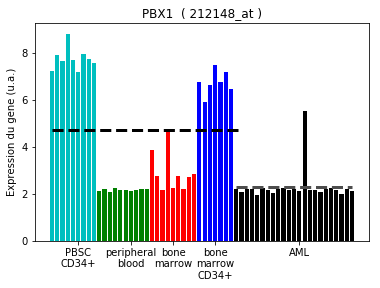

```python
def mean_expression_leukemia_normal(data,colors_cell_type):

    data_leukemia = [float(data[i]) for i,c in enumerate(colors_cell_type) if c=='k']
    data_normal = [float(data[i]) for i,c in enumerate(colors_cell_type) if c!='k']

    return (np.nanmean(data_normal),np.nanmean(data_leukemia))

def plot_gene_expression_across_conditions(data,gene,cell_type,colors_cell_type):

    # find the line in data corresponding to our gene of interest and get the gene expression levels
    idx_gene = [i for i,x in enumerate(data[:,0]) if x==gene][0]
    data_to_show = (data[idx_gene,2:]).tolist() # remove the first two elements corresponding to gene name and identifier
    data_to_show = np.array(data_to_show,dtype=float) # convert to float

    # plot the data
    fig, ax = plt.subplots()
    plt.bar(range(0,len(data_to_show)),data_to_show,color=colors_cell_type)
    plt.title(data[idx_gene,1]+'  ( '+data[idx_gene,0]+' )')
    ax.set_xticks([5,15,23,31,47])
    ax.set_xticklabels([ct.replace(' ','\n').replace('plus','+') for ct in cell_type])
    ax.set_ylabel('Expression du gene (u.a.)')

    # represent the mean gene expression in normal and cancer cells with a dashed line
    (mean_normal, mean_leukemia) = mean_expression_leukemia_normal(data_to_show,colors_cell_type)
    plt.hlines(mean_leukemia,35,57,linestyles='--',color=[0.3,0.3,0.3],lw=3) # draw a line to show mean(expression of cancer cells)
    plt.hlines(mean_normal,0,36,linestyles='--',lw=3) # draw a line to show mean(expression of normal cells)

    return idx_gene

# gene of interest
gene = '212148_at'
plot_gene_expression_across_conditions(data,gene,cell_type,colors_cell_type)
```

Vous pouvez observer que l'expression du gène PBX1 est en moyenne plus élevée dans les cellules normales (en couleur, environ 5[a.u.]) que dans les cellules cancéreuses (AML, en noir, environ 2[a.u.]).

**1.4** **(b)** A votre avis, si un médicament parvenait à augmenter l'expression du gène PBX1 dans les cellules cancéreuses à une valeur d'environ 5[u.a], est-ce qu'on serait en droit de penser que ces cellules sont à présent plus "normales"? Justifiez brièvement.

**1.4** **(c)** Par conséquent, est-ce qu'un test statistique basé sur la comparaison de l'expression moyenne d'un gène dans les cellules cancéreuses vs. dans les cellules normales (tous types cellulaires confondus) serait une bonne approche pour identifier un gène candidat comme cible d'un médicament? Justifiez brièvement.

**(a)** À vue d'oeil, non, il n'y a pas de différence significative

**(b)**

**(c)** Vu la suite de l'exercice oui

**→A présent, visualisez l'expression du gène 206067_s_at**

**1.5** Est-ce que le gène WT1 serait un meilleur candidat que PBX1 comme cible d'un médicament? Justifiez brièvement.

```python
gene = '206067_s_at'
plot_gene_expression_across_conditions(data,gene,cell_type,colors_cell_type)
```

[output not shown]

```
5593
```

Si par meilleur candidat comme cible d'un médicament qui cherche à la diminuer oui, Sinon, par cible d'un médicament qui chercherait à augmenter l'expression du gène comme dans la question précédante, non.

Car A vue d'oeil, l'expression du gène WT1 est significativement différente dans les cellules cancéreuses que les cellules normale. Ce gène pourrait être utiliser pour rechercher la maladie.

## 2a. Cibles thérapeutiques: Identifier des gènes candidats à l'aide de la corrélation

Dans cette partie, vous allez identifier des gènes exprimés différentiellement dans les cellules cancéreuses versus les cellules normales (tous types confondus) à l'aide de la corrélation.

**→ Pour cela, vous allez comparer l'expression de chaque gène avec celle du profil d'expression "desired_profile":**

```python
desired_profile = [1 if id_cond[s]=='AML' else 0 for s in data[0,2:]]
print('desired_profile = '+str(desired_profile))
```

```
desired_profile = [0, 0, 0, 0, 0, 0, 0, 0, 0, 0, 0, 0, 0, 0, 0, 0, 0, 0, 0, 0, 0, 0, 0, 0, 0, 0, 0, 0, 0, 0, 0, 0, 0, 0, 0, 1, 1, 1, 1, 1, 1, 1, 1, 1, 1, 1, 1, 1, 1, 1, 1, 1, 1, 1, 1, 1, 1, 1]
```

**→ Représentez graphiquement desired_profile.**

```
4182
```

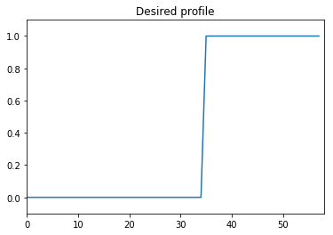

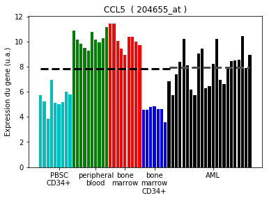

```python
fig = plt.figure()

# plot desired_profile
plt.plot(desired_profile)
plt.ylim([-0.1,1.1])
plt.xlim([0,len(desired_profile)])
plt.title('Desired profile')

# plot also gene expression data for a couple of genes to compare with desired_profile
plot_gene_expression_across_conditions(data,'206067_s_at',cell_type,colors_cell_type)
plot_gene_expression_across_conditions(data,'204655_at',cell_type, colors_cell_type)
```

[output not shown]

**2.1** A votre avis, est-ce que l'expression du gène WT1 sera significativement corrélée avec desired_profile? Et l'expression du gène CCL5? (Justifiez brièvement)

L'expression du gène WT1 sera signifiquativement corrélée avec desired_profile au contraire du gène CCL5, car, rien qu'à vue d'oeil, on peut remarqué que l'expression du gène WT1 est significativement différente dans les cellules cancéreuses que les autres, alors que CCL5 non

Afin de formaliser cette "similarité", vous allez utiliser la [corrélation de Pearson](https://en.wikipedia.org/wiki/Correlation_and_dependence) (une valeur proche de 1 signifie que les variables sont très corrélées, une valeur proche de -1 que les valeurs sont inversément corrélées, et une valeur autour de zéro que les variables ne sont pas corrélées).

**→ Calculez la corrélation de Pearson pour chaque gène présent dans le set de données et faites une représentation graphique.**

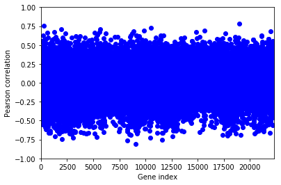

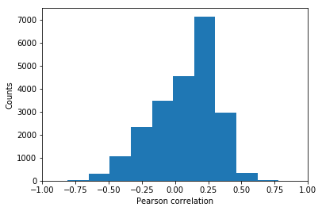

```python
def pearson_genes(data,desired_profile,show_plot=1):

    import scipy.stats as ss


    correl = [] # contains the correlation for each gene
    correl_p  = [] # for now, do not try to understand what correl_p is...

    # loop over genes
    for i in range(np.shape(data)[0]-1): # do not consider first line of data (=header)

        gene_expression = data[i+1,2:] # do not consider first two columns (= gene identifiers)
        gene_expression = np.array(gene_expression,dtype=float) # convert to float

        pearson_corr = ss.pearsonr(gene_expression,desired_profile) # calculate Pearson correlation
        correl.append(pearson_corr[0])
        correl_p.append(pearson_corr[1]) # forget about this for now...

    correl = np.array(correl,dtype=float) # convert to array... easier to manipulate

    # plot correlation values
    if show_plot:
        fig = plt.figure()
        plt.plot(correl,'bo')
        plt.ylim([-1,1])
        plt.xlim([0,len(correl)])
        plt.xlabel('Gene index')
        plt.ylabel('Pearson correlation')
        plt.show()

        plt.figure()
        plt.hist(correl)
        plt.xlabel('Pearson correlation')
        plt.ylabel('Counts')
        plt.xlim([-1,1])
        plt.show()

    return (correl,correl_p)

co = pearson_genes(data,desired_profile)
corr = co[0]
```

Comme vous le voyez, les valeurs de corrélation sont comprises entre [-1,1], avec une plus grosse densité autour de zéro. L'histogramme vous permet même de voir plus précisément qu'en fait, la majorité des valeurs de corrélation sont plutôt autour de 0.2.

A présent, votre but est d'identifier les gènes qui sont **significativement** corrélés (ou inversément corrélés) avec desired_profile. Une approche naïve consisterait à trier les gènes en fonction de leur corrélation pour ne garder que les "meilleurs". Se pose alors une question: combien de gènes garde-t-on? Doit-on éliminer tous ceux dont la valeur absolue de corrélation est plus petite que 0.5? Ou 0.75? Comment décider du seuil?

Afin de résoudre ce problème, posez-vous la question suivante: si notre set de données ne contenait *aucune* information, quelles valeurs de corrélation s'attendrait-on à obtenir? Naïvement, on pourrait penser que la corrélation serait toujours nulle. En réalité, elle sera *majoritairement* nulle, mais parfois, par pur hasard, même une assez grande valeur de corrélation pourrait être obtenue.

Pour le vérifier, vous allez randomiser les colonnes du set de données et voir quelles valeurs de corrélation seraient obtenues dans ce cas. Par randomisation des colonnes, on veut dire qu'une condition qui était préalablement labélisée "AML" pourrait maintenant être labélisée "bone marrow" à la place. Par conséquent, on s'attend à ce que les mesures de corrélation soient bien plus mauvaises avec ces données randomisées... puisque l'information utile a été randomisée.

Si jamais vous observiez que la distribution des corrélations randomisée est très similaire à la distribution des corrélations non-randomisées, c'est que le set de données ne contient pas plus d'information que du bruit!

**→ Commencez par générer des données randomisées à partir de notre set de données**

```python
def shuffle_data(data):

    from random import shuffle

    # get shuffled columns indexes
    shuffled_idx = list(range(2,np.shape(data)[1])) # ! do not shuffle the first two colums (= gene identifiers)
    shuffle(shuffled_idx) # shuffled_idx is now shuffled
    shuffled_idx.insert(0,0)
    shuffled_idx.insert(1,1)

    # use shuffled_idx to randomize the columns of data
    data_random = data[:,shuffled_idx]
    data_random[0,:] = data[0,:] # put label conditons on top again

    return data_random

data_random = shuffle_data(data)
print(str(data[3,0:5])+' = un gène NON randomisé')
print(str(data_random[3,0:5])+' = le même gène avec les conditions randomisées')
```

```
['117_at' 'HSPA6' '4.51884' '4.19324' '4.06188'] = un gène NON randomisé
['117_at' 'HSPA6' '4.24944' '4.41097' '4.21376'] = le même gène avec les conditions randomisées
```

**2.2** A l'aide de la fonction plt.hist(), comparez la distribution des corrélations dans le set randomisé vs. non-randomisé. Astuce: représentez les deux distributions sur le même graphique, avec des couleurs différentes.

```python
compare_co = pearson_genes(data,desired_profile, False)
compare_co_random = pearson_genes(data_random,desired_profile, False)
```

```
corrélation moyenne de donnée normale :  0.07586610598739306
corrélation moyenne de donnée randomisée :  0.012963430892988416
```

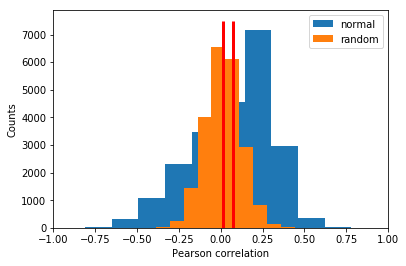

```python
plt.figure()

print("corrélation moyenne de donnée normale : ", np.mean(compare_co[0]))
print("corrélation moyenne de donnée randomisée : ", np.mean(compare_co_random[0]))
plt.vlines(np.mean(compare_co[0]),0,7500,'r',lw=3) # valeur observée = ligne verticale rouge
plt.vlines(np.mean(compare_co_random[0]),0,7500,'r',lw=3) # valeur observée = ligne verticale rouge
plt.hist(compare_co[0], label='normal')
plt.hist(compare_co_random[0], label='random')
plt.xlabel('Pearson correlation')
plt.ylabel('Counts')
plt.xlim([-1,1])
plt.legend(loc='upper right')
plt.show()
```

**2.3** A votre avis, est-ce que le set de données contient de l'information? Justifiez brièvement.

Oui, car la distribution des corrélations dans le set randomisé est différente et proche de nulle

Et maintenant? Pour chaque gène, vous avez une valeur de corrélation "observée (réelle)" et une valeur de corrélation "random". Vous pourriez donc être tenté de comparer ces deux valeurs pour ne garder que les gènes qui ont une valeur de corrélation observée plus grande que la valeur random... Mais ceci reviendrait à supposer que la valeur de corrélation random est fixée une fois pour toutes... alors qu'en fait, à chaque fois que vous allez randomiser le set de données, vous allez trouver une autre valeur de corrélation random pour chaque gène. Afin de faire des comparaisons qui aient du sens, il faudrait donc connaître, pour chaque gène, la distribution des valeurs de corrélation random, et comparer la valeur de corrélation réelle à cette distribution.

**2.4** Répétez la randomisation 10 fois: à chaque fois, calculez la corrélation à l'aide de la fonction pearson_corr().

```python
N_genes = np.shape(data)[0]-1
N_random = 10

# votre but: remplir corr_random
corr_random = np.empty((N_genes,N_random),dtype=float)

for iteration in range(N_random):
    print('---------------------- iteration n° {} ------------------------------'.format(iteration))
    current_random_data = shuffle_data(data)
    current_correlation = pearson_genes(current_random_data,desired_profile, False)

    for index in range(0, N_genes):
        corr_random[index][iteration] = current_correlation[0][index]
```

```
---------------------- iteration n° 0 ------------------------------
---------------------- iteration n° 1 ------------------------------
---------------------- iteration n° 2 ------------------------------
---------------------- iteration n° 3 ------------------------------
---------------------- iteration n° 4 ------------------------------
---------------------- iteration n° 5 ------------------------------
---------------------- iteration n° 6 ------------------------------
---------------------- iteration n° 7 ------------------------------
---------------------- iteration n° 8 ------------------------------
---------------------- iteration n° 9 ------------------------------
```

Faut-il faire plus ?

**→ Pour quelques gènes, représentez graphiquement la distribution des corrélations random ainsi que la valeur observée (le fichier random_correlation.npy contient des valeurs de corrélation obtenues en randomisant 1000 fois le set de données)**

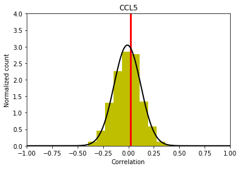

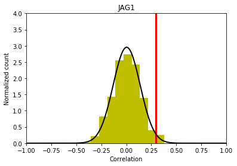

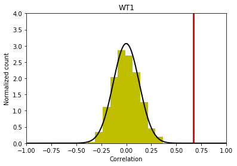

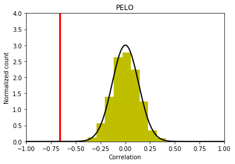

```python
from scipy.stats import norm

# load correlations from 1000 runs of randomized data
corr_random = np.load('random_correlations.npy')

# show results only for these genes
idx_genes_to_show = [4181,8590,5592,17836]

# plot: loop over idx_genes_to_show
for idx in idx_genes_to_show:
    fig = plt.figure()
    random_correlations = corr_random[idx,:]
    #plt.hist(random_correlations,normed=True,color='w') # ,normed=True # histogramme des valeurs de corrélation obtenues à partir des données randomisées
    plt.hist(random_correlations,density=1,color='y')

    plt.vlines(corr[idx],0,4,'r',lw=3) # valeur observée = ligne verticale rouge
    plt.title(data[idx+1,1]) # nom du gène
    plt.xlim([-1,1])
    plt.ylim([0, 4])
    plt.xlabel('Correlation')
    plt.ylabel('Normalized count')

    # fit gaussian to distribution of correlations from randomized data
    xx = np.linspace(-1,1,500)
    mu = np.mean(random_correlations)
    sigma = np.std(random_correlations)
    plt.plot(xx,norm.pdf(xx,loc=mu,scale=sigma),'k-',lw=2)
```

**2.5** Pour chaque gène, discutez si la valeur de corrélation obtenue semble significativement différente des valeurs obtenues en randomisant les données.

la répartition des corrélations pour WT1 et PELO semble significativement différente des valeurs obtenues en randomisant les données, au contraire de CCL5 qui ne pourrait en aucun cas nous aider plus tard. Et nous pouvons à la limite considérer JAG1, mais si on a mieux, autant prendre le mieux.

Afin de quantifier à quel point la corrélation observée est différente de la distribution des corrélations obtenue en randomisant les données, vous allez calculez la p-valeur de la corrélation observée pour chaque gène. La p-valeur est la probabilité d'obtenir, par hasard, une valeur absolue de corrélation au moins aussi grande.

**→ Pour chaque gène, calculez la probabilité d'obtenir par hasard une valeur de corrélation aussi grande (ou plus) que la valeur absolue observée.** Pour vous aider à mieux comprendre ce concept, le script ci-dessous représente graphiquement la p-valeur (aire sous la courbe hachurée en noir) pour le premier gène.

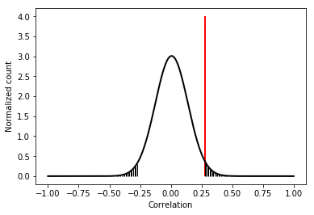

```python
N_genes = np.shape(data)[0]-1 # number of genes in the data

pval_correl = [] # p-values
for idx in range(0,N_genes):

    # random correlation: calculate mean and standard deviation
    random_correlations = corr_random[idx,:]
    mean_random = np.mean(random_correlations)
    std_random = np.std(random_correlations)

    # observed correlation
    observed_correlation = corr[idx]

    # cdf: cumulative distribution function = integral of the gaussian distribution from -inf to observed_correlation
    cdf = norm.cdf(observed_correlation,loc=mean_random,scale=std_random)
    if cdf >= 0.5:
        p = 1 - cdf
    else:
        p = cdf
    pval_correl.append(2*p) # factor 2 because correlations can take both positive and negative values


    # show p-value visually for the first gene (p-value = area of black hatched regions under the curve)
    if idx==0:
        plt.figure()
        plt.plot(xx,norm.pdf(xx,loc=mean_random,scale=std_random),'k-',lw=2)
        plt.vlines(corr[idx],0,4 ,'r',lw=2)
        for j in np.linspace(observed_correlation,1,int(100*(1-observed_correlation))):
            plt.vlines(j,0,norm.pdf(j,loc=mean_random,scale=std_random),'k',lw=1)
        for j in np.linspace(-1,-observed_correlation,int(100*(1-observed_correlation))):
            plt.vlines(j,0,norm.pdf(j,loc=mean_random,scale=std_random),'k',lw=1)
        plt.xlabel('Correlation')
        plt.ylabel('Normalized count')
        plt.show()
```

Les gènes qui nous intéressent sont ceux pour lesquels la p-valeur est très petite. Mais qu'est-ce qu'une "petite" p-valeur? Prenons par exemple un gène qui aurait une p-valeur de 0.05. Dans notre cas, cela signifie que la probabilité que ce gène ait, *par hasard*, une valeur absolue de corrélation au moins aussi grande est égale à 5% (5%=5/100=0.05). En sciences de la vie et en médecine, il est communément admis qu'une p-valeur inférieure à 0.05 est significative... Qu'est-ce que cela signifierait dans notre cas?

Dans notre cas, nous sommes en train d'effectuer 22283 tests (un test pour chaque gène). Si l'on garde un seuil pour la p-valeur de 0.05, cela représente potentiellement 1114 gènes qui pourraient avoir une p-valeur significative par pur hasard (puisqu'en tirant des valeurs de corrélation au hasard, 5% de ces valeurs seront au moins aussi grandes que la valeur de corrélation observée)! Dans le cas de tests multiples, il est donc nécessaire d'abaisser le seuil de p-valeur... Reste à savoir de combien...

**→ Pour vous faire une idée, représentez graphiquement vos p-valeurs à l'aide d'un "Volcano plot".**

Notez que par commodité, on utilise souvent -log10(p-valeur) pour représenter les p-valeurs. Dans ce cas,

> si p-valeur=10^[-21], alors

> -log10(p-valeur)=21.

Ce qui revient à dire que dans cette notation, les gènes les plus importants sont ceux dont le -log10(p-val) est le plus grand... Attention aux confusions!

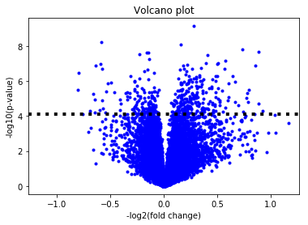

```python
import stats
stats.volcano_plot(data[1:,2:],desired_profile,pval=pval_correl)
```

Dans cette représentation, chaque point bleu est un gène. Les gènes intéressants sont ceux qui sont dans les "coins" supérieurs droit et gauche, c'est-à-dire les gènes qui ont une p-valeur très petite, et pour lequel le ratio "expression du gène dans les cellules cancéreuses SUR expression du gène dans les cellules normales" est grand.

Sur ce plot, une ligne horizontale est également dessinée en traitillé: c'est le seuil qui a été calculé pour la significance, ce qui signifie que seuls les gènes au-dessus de la ligne ont une p-valeur suffisamment petite.

Comment ce seuil a-t-il été calculé? Il existe plusieurs méthodes pour abaisser ce seuil, plus ou moins conservatives. La méthode de Bonferroni, très conservative, détermine le seuil de probabilité pour lequel au moins un faux positif sera identifié. Seules les p-valeurs inférieures à ce seuil sont admises. D'autres méthodes préfèrent contrôler la proportion de faux positifs qui sont admis ([FDR correction](https://en.wikipedia.org/wiki/False_discovery_rate)). C'est la méthode qui a été utilisée ici.

**→ Identifiez les gènes pour lesquels: -log10(p-valeur) > 4.11 (équivalent à un FDR de 5%, i.e. parmi les gènes identifiés comme significatifs, seuls 5% d'entre eux risquent d'être de faux positifs).**

```
-log10(p-value FDR) = 4.118650556685259
```

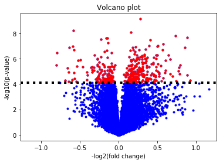

```
368 significant genes found with correlation (after p-value correction):
['PLD1' 'APP' 'CTSA' 'CD63' 'UBE2L3' 'GPX1' 'TPP1' 'ATF4' 'PAFAH1B1'
 'AHCYL1' 'CNOT1' 'ABLIM1' 'ACTA2' 'CD59' 'CD59' 'CD59' 'LOC100093631'
 'SON' 'LGALS1' 'PLP2' 'NFE2L2' 'BTG2' 'ENO2' 'IVNS1ABP' 'IVNS1ABP'
 'MAPKAPK2' 'DUSP3' 'LAMP1' 'KDM3B' 'TIMP1' 'HMCES' 'TPD52' 'HEXA' 'LBR'
 'RYBP' 'CAPG' 'KIF5B' 'ST6GAL1' 'DYNLT1' 'ZNF410' 'KPNA1' 'CTR9' 'TRAK2'
 'AREL1' 'NUP62' 'PLOD3' 'LIMK2' 'NFYC' 'CRK' 'BRD8' 'TDP2' 'MAML1' 'SRF'
 'DBI' 'LPIN2' 'LPIN2' 'TRIB2' 'GMFB' 'VAPB' 'EPS8' 'SERTAD2' 'RNMT'
 'OXSR1' 'DUSP11' 'FOXO1' 'FOXO1' 'PDCD4' 'AHR' 'DNAJB9' 'RALBP1' 'FHL2'
 'STK38' 'FAM13A' 'MEF2D' 'CYBA' 'KIF2A' 'SRPK2' 'NUP98' 'NUP98' 'MAP2K4'
 'IRF2' 'KIAA0355' 'ARF6' 'NCK2' 'LMNA' 'MMD' 'ARMC8' 'ZHX2' 'NDUFB6'
 'IGF1R' 'FMR1' 'EMP3' 'SLA' 'BLVRA' 'BLVRA' 'MRPL33' 'GCLM' 'PURA'
 'RARRES3' 'TOPORS' 'P2RX4' 'STAB1' 'CEBPG' 'PIM2' 'APOC2' 'SELL' 'PKIA'
 'HOMER3' 'ISG20' 'PTGS2' 'BTN3A2' 'BTN3A3' 'NME3' 'STAT5B' 'IKZF1'
 'CD79A' 'IDUA' 'CSF2RB' 'ATP7A' 'NMB' 'KCNH2' 'SLC15A2' 'DAG1' 'CRLF3'
 'DIAPH2' 'SCYL3' 'PIP5K1B' 'F8' 'BIK' 'SKAP1' 'RASGRP3' 'CCNA1' 'GTF2E1'
 'WT1' 'TPM1' 'STAT4' 'CD33' 'IL3RA' 'CLC' 'IVNS1ABP' 'S1PR4' 'PLXNC1'
 'LTC4S' 'GFI1' 'SEPT5' 'FLT3' 'MAPK6' 'BTN3A1' 'P4HA1' 'CUL1' 'ATP6AP1'
 'MAEA' 'AMPD3' 'RUNX1' 'ST3GAL1' 'BAZ1B' 'XPNPEP1' 'SUMO1'
 'ANKHD1-EIF4EBP3' 'ANKHD1-EIF4EBP3' 'CSNK1D' 'ELOVL5' 'SEC62' 'ERP44'
 'STAG2' 'XPNPEP1' 'ZMYND8' 'NCOA3' 'JAG1' 'JAG1' 'CDKN1B' 'HBB' 'SART3'
 'USP10' 'MFSD10' 'BCL2L2' 'ABCC5' 'DBI' 'COA1' 'SYNE1' 'USP15' 'MBD4'
 'PRUNE' 'GATA3' 'AP1S1' 'CDKN2A' 'PIGK' 'SERPINB9' 'NPAT' 'BTN3A2' 'FUT4'
 'FUT4' 'NFE2' 'EPOR' 'ORC3' 'PRKCQ' 'TAF5' 'PNN' 'TNFAIP8' 'RUNX1' 'ELK1'
 'TUBD1' 'GATA1' 'KLF1' 'CCL23' 'KDM3B' 'PDCD10' 'CD44' 'PFKM' 'TPM1'
 'PRUNE' 'DBI' 'GGT1' 'CHRNA3' 'HBB' 'BLVRA' 'BAX' 'TBC1D9B' 'LMNA' 'LMNA'
 'PBX1' 'CRKL' 'MRFAP1L1' 'ALDH1A1' 'MTMR4' 'MYH10' 'FEM1B' 'IP6K1'
 'RMND5A' 'ZNF24' 'BRD3' 'STAT5B' 'STAT5B' 'SORL1' 'BTN3A2' 'HIVEP2'
 'HIVEP2' 'JADE2' 'SMURF1' 'MSL1' 'GAPVD1' 'IGHM' 'PIP4K2A' 'TSPYL5' 'SP3'
 'GLTSCR1L' 'PLXNC1' 'TRANK1' 'MBOAT2' 'PLCL2' 'ZC3H4' 'IQCK' 'COL6A1'
 'MAPRE2' 'F2RL1' 'KPNB1' 'MTMR1' 'SON' 'ATP6V0E2' 'NUP50' 'RSBN1'
 'Z23022' 'CCDC22' 'MBD4' 'LMNA' 'MTMR4' 'IDH3G' 'TPM3' 'SON' 'MAPKAPK2'
 'C15orf39' 'PRKCA' 'HOMER3' 'AU146791' 'AU144530' 'CYFIP2' 'RLIM' 'NAB2'
 'PSMA7' 'MTMR1' 'PLCL2' 'JAG1' 'GRHPR' 'AK024995' 'SOD2' 'FAM13A' 'HBB'
 'MILR1' 'CD44' 'SERF2' 'ASNSD1' 'MAT2B' 'RPS27L' 'UFM1' 'ERGIC2' 'PRKD3'
 'DDA1' 'NUP50' 'TACC3' 'HAUS4' 'CAPRIN2' 'PELO' 'JADE1' 'FAM134B' 'PTBP2'
 'SDPR' 'LXN' 'RNF111' 'PRKCH' 'CUTC' 'RNF34' 'FKBP11' 'FKBP11' 'GTF3C4'
 'BAHCC1' 'MOB3B' 'C3orf14' 'RNF219' 'TMEM204' 'CNTNAP1' 'DERL1' 'TTC33'
 'CLUHP3' 'MARC2' 'NRIP3' 'BAG4' 'PCDH9' 'MEPCE' 'NARF' 'CSDE1' 'BANP'
 'HIVEP3' 'MTHFD2L' 'SAP130' 'CNNM3' 'DPP8' 'ARPC5L' 'SFXN3' 'CYFIP2'
 'TSPAN14' 'TMCO6' 'MAP3K19' 'BACH2' 'FAM117A' 'SGPP1' 'SOD2' 'CDC14B'
 'LEF1' 'CORO1B' 'FAM46A' 'MPHOSPH8' 'GPR124' 'MARCH8' 'LUZP1' 'SYNRG'
 'OSER1' 'TOPORS-AS1' 'RHOT1' 'FGFR1' 'MAP4' 'AGPAT2' 'ISG20' 'BTN3A3'
 'PRDX2' 'FBXO41' 'BMP2K' 'SYNRG' '91682_at']
```

```python
# Multiple-testing-corrected p-value
fdr_pval = stats.fdr_correction(pval_correl)
print('-log10(p-value FDR) = '+str(-np.log10(fdr_pval))+'\n')

# idx of genes with p-value < fdr_pval
idx_sg_corr = np.array([i for i,p in enumerate(pval_correl) if p<fdr_pval])

# Volcano plot that shows significant genes in red
stats.volcano_plot(data[1:,2:],desired_profile,pval=pval_correl,idx=idx_sg_corr)

# print name of most significant genes
print(str(len(idx_sg_corr))+' significant genes found with correlation (after p-value correction): \n'+str(data[idx_sg_corr+1,1]))
```

**→ Utilisez un heatmap pour visualiser l'expression de ces gènes.** Notez que pour la visualisation, les gènes sont aussi regroupés en fonction de leur similarité (clustering hiérarchique, voir dendrogram sur la gauche).

```python
import matplotlib
import scipy.cluster.hierarchy as cl
import scipy.spatial.distance as ssd

def show_matrix_expression(data,idx_genes,id_cond,dim=(16,10),show_ylabels=True):

    # data: matrix of data with headers
    # idx_genes: idx of genes

    if isinstance(idx_genes,list):
        idx_genes = np.array(idx_genes,dtype=int)

    conditions = data[0,2:]
    genes = data[:,1]
    data_to_show = data[idx_genes+1,2:]

    # re-order genes using hierarchical clustering
    fig = plt.figure(num=None,figsize=(dim),dpi=250)
    ax1 = fig.add_axes([0.09,0.1,0.2,0.6])
    dmat = ssd.pdist(data_to_show,'cosine')
    Z = cl.linkage(ssd.squareform(dmat),method='average',metric='cosine')
    Z = cl.dendrogram(Z,orientation='left',no_labels=True)
    idx_reorder = Z['leaves']
    data_to_show = data_to_show[idx_reorder,:]


    # plot heatmap
    ax = fig.add_axes([0.3,0.1,0.6,0.6])
    data_to_show = data_to_show.astype(float)
    heatmap = ax.pcolor(data_to_show, cmap=plt.cm.YlGnBu,vmin=0,vmax=12)

    ## pour faire joli...............................................................................

    # put the major ticks at the middle of each cell
    ax.set_xticks(np.arange(data_to_show.shape[1])+0.5, minor=False)
    ax.set_yticks(np.arange(data_to_show.shape[0])+0.5, minor=False)

    # frame and labels position...
    ax.set_frame_on(False)
    ax.xaxis.tick_top()
    ax.grid(False)
    plt.xlim([0,np.shape(data_to_show)[1]])
    plt.ylim([0,np.shape(data_to_show)[0]])

    # set xlabels and ylabels
    if show_ylabels:
        ax.set_yticklabels([genes[ii+1] for ii in idx_genes], minor=False)
    else:
        ax.yaxis.tick_right()
        ax.set_yticklabels([genes[ii+1] for ii in idx_genes])
    conditions = [id_cond[s] for s in conditions]
    ax.set_xticklabels(conditions, minor=False)

    # rotate tick labels and set size
    plt.xticks(rotation=90) # rotate xlabels
    matplotlib.rcParams['xtick.labelsize'] = 10

    plt.show()

show_matrix_expression(data,idx_sg_corr,id_cond,dim=(10,85),show_ylabels=False)
```

```
c:\users\vincent guidoux\.conda\envs\bbc1\lib\site-packages\ipykernel_launcher.py:21: ClusterWarning: scipy.cluster: The symmetric non-negative hollow observation matrix looks suspiciously like an uncondensed distance matrix
```

[figure not shown]

**2.6** A vue d'oeil, qu'est-ce qui caractérise les gènes regroupés en rouge dans le dendrogram, par rapport à ceux regroupés en vert? (100 mots maximum)

Vous venez d'identifier 368 gènes dont l'expression est significativement différente dans les cellules cancéreuses (AML) vs. les autres types cellulaires normaux. Pour y parvenir, vous avez dû

- calculer la p-valeur associée à chaque corrélation en estimant la distribution des corrélations obtenue avec des données randomisées.
- déterminer un seuil de p-valeur: seuls les gènes ayant une p-valeur inférieure à ce seuil ont été retenus comme significativement corrélés.

Comme vous le verrez si vous restez dans le domaine de la bioinformatique, la p-valeur est une notion extrêment utilisée en sciences de la vie et en médecine pour rejeter des hypothèses "nulles" (oui, c'est leur vrai nom). Dans notre cas, l'hypothèse nulle est donnée par la distribution des corrélations obtenues avec les données randomisées (équivalent à dire que l'expression des gènes ne contient pas d'information utile). Pour les 368 gènes identifiés, vous avez rejeté l'hypothèse nulle, car la probabilité que la valeur de corrélation observée soit issue de cette distribution "nulle" était extrêmement faible.

A présent que vous avez bien compris ce qu'est une p-valeur, on avoue... La fonction pearson_genes() définie plus haut retourne deux variables: la corrélation de chaque gène, et sa p-valeur. Mais rassurez-vous, vous n'avez pas fait tout ça pour rien... L'exercice en valait la peine, non?

**→ Avant de passer à la partie suivante, vérifiez que vos p-valeurs empiriques et celles retournées par pearson_genes() sont bien similaires (i.e. elles sont réparties le long de la diagonale, plus ou moins).**

```
(0, 1)
```

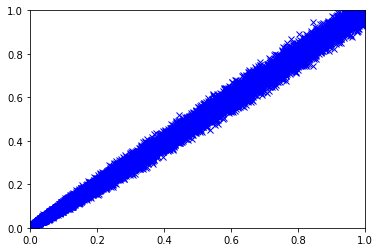

```python
plt.figure()
plt.plot(co[1],pval_correl,'bx')
plt.xlim([0,1])
plt.ylim([0,1])
```

**→ DANS LA "VRAIE" VIE...** Une méthode statistique a déjà été développée pour identifier des gènes significatifs et s'appelle la ["Significance Analysis of Microarrays" (SAM)](http://statweb.stanford.edu/~tibs/SAM/). Cette méthode statistique est essentiellement basée sur les concepts développés dans ce labo. Elle est disponible dans R, Excel, [python](http://acc.crs4.it/acdc/pygsa/) et dans le [MultiExperiment Viewer (MeV)](http://www.tm4.org/mev.html) téléchargeable gratuitement.

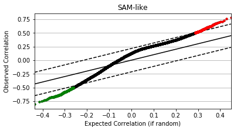

```python
## -- SAM-like with correlation -- ##

# correlation per gene, random correlation per gene
corr_S = np.sort(corr)
corr_random_S = np.sort(corr_random,0)
corr_random_mean = np.mean(corr_random_S,1)

# significance thresholds: get approximation of delta for FDR ~ 5%
corr_fdr = norm.ppf(1-fdr_pval/2.0,loc=np.mean(corr_random_mean),scale=np.std(corr_random_mean))

idx_sign_up = [i for i,c in enumerate(corr_S) if c>=corr_fdr]
idx_sign_down = [i for i,c in enumerate(corr_S) if c<=-corr_fdr]
delta = corr_fdr - corr_random_mean[idx_sign_up[0]]

# plot
plt.figure(figsize=(6,3))
plt.plot(corr_random_mean,corr_S,'k.')
plt.xlabel('Expected Correlation (if random)')
plt.ylabel('Observed Correlation')
plt.gca().yaxis.grid(True)
plt.title('SAM-like')
minx = min(corr_random_mean)
maxx = max(corr_random_mean)
plt.xlim([minx,maxx])
xx = np.linspace(minx,maxx,10)
plt.plot(xx,xx,'k-')
plt.plot(xx,xx+delta,'k--')
plt.plot(xx,xx-delta,'k--')
plt.plot(corr_random_mean[idx_sign_up],corr_S[idx_sign_up],'r.')
plt.plot(corr_random_mean[idx_sign_down],corr_S[idx_sign_down],'g.')

# show screenshot of MeV software
from PIL import Image
img = Image.open('SAM_MeV.png')
img.show()
```

## 2b. Cibles thérapeutiques: Améliorer la liste obtenue à l'aide du t-test et visualiser la matrice des candidats finaux.

Vous l'avez vu, la méthode de corrélation de Pearson est extrêmement simple. C'est une analyse univariée ("un gène à la fois"), et pour identifier les gènes significatifs, vous avez seulement dû calculer la corrélation avec un profil désiré.

Le seul souci avec cette méthode très simple, c'est qu'il est possible d'identifier des gènes candidats pour lesquels l'expression dans les cellules cancéreuses est similaire à l'expression dans un type cellulaire normal, même si, globalement, les niveaux d'expression sont différents dans les cellules cancéreuses vs. les cellules normales (tous types confondus).

**→ Rappelez-vous du gène PBX1, identifié comme significatif avec la corrélation.**

```
11534
```

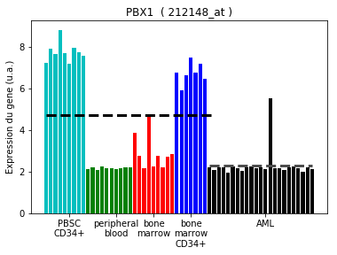

```python
plot_gene_expression_across_conditions(data,'212148_at',cell_type,colors_cell_type)
```

Pour améliorer notre liste et s'assurer que chaque gène candidat pris individuellement est un bon candidat comme cible thérapeutique, nous allons donc utiliser le t-test. L'idée derrière le t-test est de comparer deux distributions de données pour savoir si elles sont très similaires ou pas.

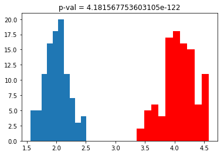

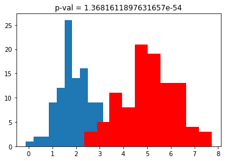

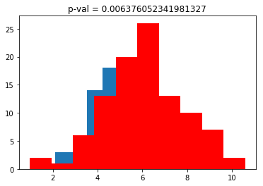

```python
from scipy.stats import ttest_ind

def plot_distrib(mu1,mu2,s1,s2):
    N = 100
    x = np.linspace(0,10,N)
    y1 = norm.rvs(loc=mu1,scale=s1,size=N)
    y2 = norm.rvs(loc=mu2,scale=s2,size=N)
    plt.figure()
    plt.hist(y1)
    plt.hist(y2,color='r')
    p = ttest_ind(y1,y2,equal_var=False)[1]
    plt.title('p-val = '+str(p))

plot_distrib(2,4,0.2,0.3)
plot_distrib(2,5,0.8,1.2)
plot_distrib(5.8,6,1.7,1.8)
```

**2.7** Discutez brièvement à quoi sert le t-test. (100 mots maximum)

Nous pouvons utiliser ce test si nous observons deux échantillons indépendants de la même population ou d’une population différente, par exemple: les résultats aux examens de garçons et de filles ou de deux groupes ethniques. Le test mesure si la valeur moyenne (attendue) diffère de manière significative d'un échantillon à l'autre. Si nous observons une grande valeur p, par exemple supérieure à 0,05 ou 0,1, nous ne pouvons pas rejeter l'hypothèse nulle de scores moyens identiques. Si la valeur p est inférieure au seuil, par ex. 1%, 5% ou 10%, alors nous rejetons l'hypothèse nulle des moyennes égales.

[scipy.stats.ttest_ind](https://docs.scipy.org/doc/scipy/reference/generated/scipy.stats.ttest_ind.html)

à modifier, copié.collé docs

Dans notre cas, nous aimerions trouver des gènes pour lesquels la distribution des niveaux d'expression est très différente dans les cellules cancéreuses par rapport aux cellules normales (quel que soit le type choisi). On pourrait donc utiliser le t-test pour vérifier que nos candidats trouvés à l'aide de la corrélation satisfont la condition suivante: l'expression dans les cellules cancéreuses est significativement différente de l'expression dans *chaque* type cellulaire normal.

**→ Pour chaque gène, testez à l'aide du t-test si son expression dans les cellules cancéreuses est significativement différente de son expression dans chaque type cellulaire normal** (ceci peut prendre quelques minutes).

```python
from scipy.stats import ttest_ind

N_genes = np.shape(data)[0]-1 # number of genes
idx_leukemia = [i+2 for i,c in enumerate(data[0,2:]) if id_cond[c]=='AML'] # column idx with leukemia

# perform t-test between cancer cell type and each normal cell type
pval_ct = [] # p-value across cell types
for k,ct in enumerate(cell_type[:-1]):

    idx_normal = [i+2 for i,c in enumerate(data[0,2:]) if id_cond[c]==ct] # column idx corresponding to a cell type

    pval = []
    for g in range(1,N_genes+1): # loop over genes

        normal = np.array(data[g,idx_normal],dtype=float)
        leukemia = np.array(data[g,idx_leukemia],dtype=float)
        ttest = ttest_ind(normal,leukemia,equal_var=False) # return t-value and its associated p-value
        pval.append(ttest[1])
    pval_ct.append(pval)
```

**→ Pour finir, gardez uniquement les gènes pour lesquels la p-valeur de chaque t-test, ainsi que de la corrélation, est très petite (critère FDR vu précédemment).**

```python
import importlib

# fdr correction
importlib.reload(stats)
fdr_pval = [stats.fdr_correction(pval_ct[ct]) for ct in range(len(pval_ct))]

# keep genes for which the t-test p-value is smaller than the fdr-corrected threshold (fdr_pval)
idx_sg_ttest = []
for i in range(N_genes):
    significant = [1 if pval_ct[ct][i]<fdr_pval[ct] else 0 for ct in range(len(pval_ct))]
    if sum(significant)==4:
        idx_sg_ttest.append(i)


# keep only genes that appear significantly in each t-test AND in the correlation test
idx_sg_final = np.array( list( set(idx_sg_ttest) & set(idx_sg_corr) ) )

print('LISTE FINALE DE GENES:\n'+str(data[idx_sg_final+1,1]).strip('[]'))
```

```
LISTE FINALE DE GENES:
'GPX1' 'HOMER3' 'JAG1' 'IL3RA' 'BAG4' 'AHR' 'CDKN2A' 'CCNA1'
 'ANKHD1-EIF4EBP3' 'PLXNC1' 'MTMR4' 'IKZF1' 'TRIB2' 'WT1' 'ALDH1A1'
 'CHRNA3' 'MBD4' 'PRUNE' 'CORO1B'
```

**2.8** Utilisez plot_gene_expression_across_conditions() pour représenter graphiquement l'expression des candidats finaux.

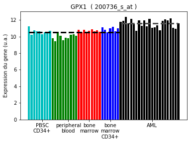

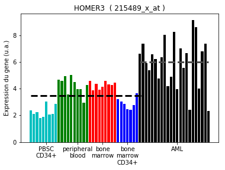

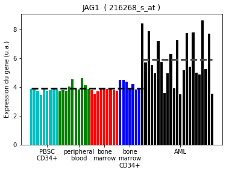

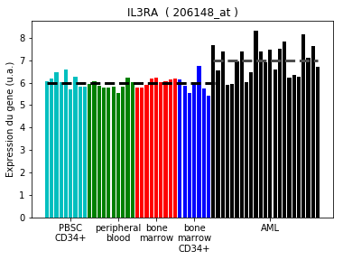

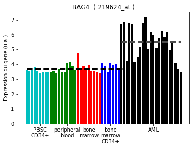

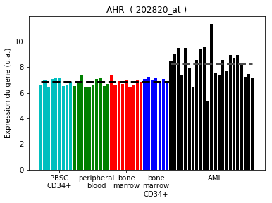

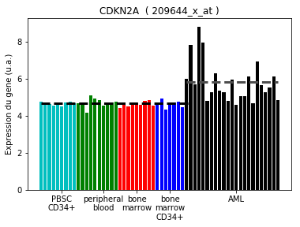

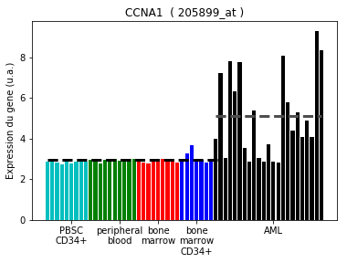

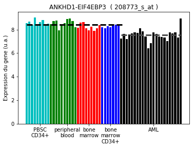

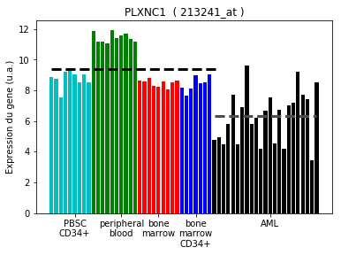

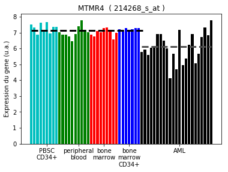

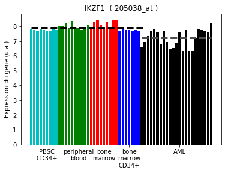

[6 more figures not shown]

```python
final_candidates_gene = data[idx_sg_final+1,0]

for candidat in final_candidates_gene:
    plot_gene_expression_across_conditions(data,candidat,cell_type,colors_cell_type)
```